# FigureYa7PSM

**Author(s)**: Ying Ge; Yijing Chen  
**Date**: 2025-09-22

# Academic Citation

If you use this code in your work or research, we kindly request that you cite our publication:

Xiaofan Lu, et al. (2025). FigureYa: A Standardized Visualization Framework for Enhancing Biomedical Data Interpretation and Research Efficiency. iMetaMed. https://doi.org/10.1002/imm3.70005

## 需求描述

## Requirement description

主要目的是在病例组数据集和对照组数据集里面进行快速的1:1匹配。要求性别相同，年龄不超过两岁。虽然不是作图的。但估计群里好多临床的人肯定也特别想用的。如果CASE1和CONTROL1匹配后，那么就算CASE3和CONTROL1也可以匹配，但是也不能匹配了。

实质上，需求者是想做倾向得分匹配。倾向得分匹配（PSM）是一种用来评估处置效应的统计方法。广义说来，它将样本根据其特性分类，而不同类样本间的差异就可以看作处置效应的无偏估计。因此，PSM不仅仅是随机试验的一种替代方法，它也是流行病研究中进行样本比较的重要方法之一。

有R包已经把各种情况考虑进去，帮助我们轻松的完成倾向得分匹配。

The main purpose is to quickly achieve 1:1 matching between the case group dataset and the control group dataset. The requirements are that the gender must be the same and the age difference should not exceed two years. Although this is not intended for plotting, it’s likely that many people in the clinical group would want to use it. If CASE1 and CONTROL1 are matched, then even if CASE3 and CONTROL1 could also be matched, they should not be.

Essentially, the requester wants to perform propensity score matching. Propensity score matching (PSM) is a statistical method used to evaluate treatment effects. Generally speaking, it categorizes samples based on their characteristics, and the differences between these categories can be considered an unbiased estimate of the treatment effect. Therefore, PSM is not only an alternative to randomized trials but also an important method for comparing samples in epidemiological research.

R packages have already accounted for various scenarios, making it easy for us to perform propensity score matching.

## 使用场景

## Usage scenario

与健康相关的生活质量（HRQOL）被认为是癌症治疗的重要结果之一。对癌症患者而言，最常用的HRQOL测度是通过欧洲癌症研究与治疗中心的调查问卷计算得出的。EORTC QLD-C30是一个由30个项目组成，包括5个功能量表，9个症状量表和一个全球生活质量量表的的问卷。所有量表都会给出一个0-100之间的得分。症状量表得分越高代表被调查人生活压力越大，其余两个量表得分越高代表生活质量越高。

然而，如果没有任何参照，直接对数据进行解释是很困难的。幸运的是，EORTC QLQ-C30问卷也在一些一般人群调查中使用，我们可以对比患者的得分和一般人群的得分差异，从而判断患者的负担症状和一些功能障碍是否能归因于癌症治疗。PSM在这里可以以年龄和性别等特征，将相似的患者和一般人群进行匹配。

代码和说明信息来源于以下资料：

原文：https://datascienceplus.com/how-to-use-r-for-matching-samples-propensity-score/

译文：http://www.ituring.com.cn/article/260460

Health-related quality of life (HRQOL) is considered one of the important outcomes of cancer treatment. For cancer patients, the most commonly used HRQOL measure is calculated using the questionnaire from the European Organisation for Research and Treatment of Cancer. The EORTC QLQ-C30 is a questionnaire consisting of 30 items, including 5 functional scales, 9 symptom scales, and a global health status scale. All scales provide a score between 0 and 100. A higher score on the symptom scales indicates greater life stress for the respondent, while higher scores on the other two scales indicate a better quality of life.

However, interpreting data directly without any reference is challenging. Fortunately, the EORTC QLQ-C30 questionnaire is also used in some general population surveys, which allows us to compare the scores between patients and the general population. This comparison helps determine whether the burden of symptoms and certain functional impairments in patients can be attributed to cancer treatment. PSM can match similar patients with the general population based on characteristics such as age and gender.

The code and description information is taken from the following sources:

original text: https://datascienceplus.com/how-to-use-r-for-matching-samples-propensity-score/

translation: http://www.ituring.com.cn/article/260460

## 生成输入数据

## Generate input data

如果你自己有数据，保存成easy_input.txt那样的格式，就可以跳过“生成输入数据”这步，直接进入“倾向得分匹配”；

If you have your own data, save it in easy_input.txt format, you can skip the “Generate Input Data” step and go directly to “Propensity Score Matching”;

### 生成患者人群

### Generate a patient population

创建一个名为df.patients的数据框，我希望它包含250个病人的年龄和性别数据，所有病人的年龄都要在30-78岁之间，并且70%的病人被设定为男性。

Create a dataframe called df.patients, I would like it to contain age and gender data for 250 patients, all of which should be between 30-78 years old and 70% of which are set to be male.

```r
source("install_dependencies.R")
```

```
## Starting R package installation...
## ===========================================
##
## Installing CRAN packages...
## Package already installed: MatchIt
## Package already installed: wakefield
##
## ===========================================
## Package installation completed!
## You can now run your R scripts in this directory.
```

```r
#install.packages("wakefield")
library(wakefield)
set.seed(1234)
df.patients <- r_data_frame(n = 250,
                            age(x = 30:78,
                                name = 'Age'),
                            sex(x = c("Male", "Female"),
                                prob = c(0.70, 0.30),
                                name = "Sex"))
df.patients$Sample <- as.factor('CASE')
df.patients$ID<-paste("CASE",rownames(df.patients),sep = "")
summary(df.patients)
```

```
##       Age            Sex       Sample         ID
##  Min.   :30.00   Male  :163   CASE:250   Length:250
##  1st Qu.:42.00   Female: 87              Class :character
##  Median :52.00                           Mode  :character
##  Mean   :53.51
##  3rd Qu.:65.00
##  Max.   :78.00
```

### 生成正常对照人群

### Generate a normal control population

创建一个名为df.population的数据框。我希望这个数据集的数据和患者的有些不同，因此正常人群的年龄区间被设定为18-80岁，并且男女各占一半。

Create a dataframe called df.population. I want the data in this dataset to be a little different from the patient’s, so the age range for the normal population has been set to 18-80, with an equal distribution of males and females.

```r
set.seed(1234)
df.population <- r_data_frame(n = 1000,
                              age(x = 18:80,
                                  name = 'Age'),
                              sex(x = c("Male", "Female"),
                                  prob = c(0.50, 0.50),
                                  name = "Sex"))
df.population$Sample <- as.factor('CONTROL')
df.population$ID<-paste("CONTROL",rownames(df.population),sep = "")
summary(df.population)
```

```
##       Age            Sex          Sample          ID
##  Min.   :18.00   Male  :487   CONTROL:1000   Length:1000
##  1st Qu.:34.00   Female:513                  Class :character
##  Median :49.00                               Mode  :character
##  Mean   :49.06
##  3rd Qu.:64.00
##  Max.   :80.00
```

### 合并人群

### Merge populations

把上面这两个数据框合并，也就是把患者混进正常人群，这样就模拟出一个自然人群，完成了全部的准备工作。

Merging these two data frames above, mixing the patients into the normal population, thus simulating a natural population, completes all the preparations.

```r
mydata <- rbind(df.patients, df.population)
mydata$Group <- as.logical(mydata$Sample == 'CASE')
head(mydata)
```

```
## # A tibble: 6 × 5
##     Age Sex    Sample ID    Group
##   <int> <fct>  <fct>  <chr> <lgl>
## 1    57 Male   CASE   CASE1 TRUE
## 2    45 Male   CASE   CASE2 TRUE
## 3    51 Male   CASE   CASE3 TRUE
## 4    66 Male   CASE   CASE4 TRUE
## 5    73 Female CASE   CASE5 TRUE
## 6    76 Male   CASE   CASE6 TRUE
```

```r
tail(mydata)
```

```
## # A tibble: 6 × 5
##     Age Sex    Sample  ID          Group
##   <int> <fct>  <fct>   <chr>       <lgl>
## 1    76 Female CONTROL CONTROL995  FALSE
## 2    67 Male   CONTROL CONTROL996  FALSE
## 3    69 Female CONTROL CONTROL997  FALSE
## 4    51 Female CONTROL CONTROL998  FALSE
## 5    41 Male   CONTROL CONTROL999  FALSE
## 6    74 Male   CONTROL CONTROL1000 FALSE
```

```r
write.table(mydata,"easy_input.txt",row.names = F,quote = F,sep = "\t")
```

## 倾向得分匹配

## Propensity score matching

生成匹配的病例组数据集和对照组数据集

用MatchIT包中的matchit函数来匹配两类样本

Generate matched case group dataset and control group dataset

The matchit function from the MatchIT package is used to match two types of samples

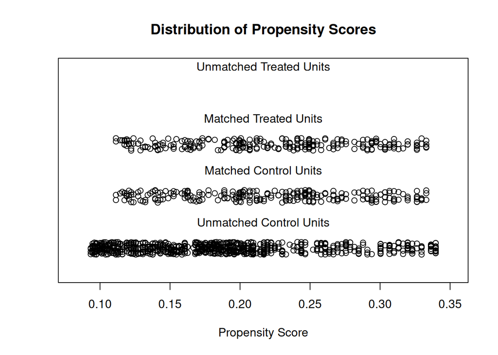

```r
#install.packages("MatchIt")
library(MatchIt)
#要找年龄最接近的，因此选用method=‘nearest’。
#ratio=1意味着这是一一配对
#同时也请注意Group变量需要是逻辑型变量
#To find the nearest age, use method='nearest'.
#ratio=1 means this is a one-to-one pairing
#Please also note that Group variables need to be logical variables
set.seed(1234)
match.it <- matchit(Group ~ Age + Sex, data = mydata, method="nearest", ratio=1)
plot(match.it, type = 'jitter', interactive = FALSE)
```

## 生成CASE-CONTROL一一配对的格式

## Generate CASE-CONTROL one-to-one matching format

```r
df.match <- match.data(match.it)[1:ncol(mydata)]
df<-df.match[order(df.match$Age),]#按年龄排序 sort by age
df<-df[order(df$Sex),]#按性别排序 sort by gender
df<-df[order(df$Group),]#按组排序 sort by Group
#配对
#match
dfpairinfo<-data.frame(df$ID[1:250],df$Age[1:250],df$Sex[1:250],df$ID[251:500],df$Age[251:500],df$Sex[251:500])
colnames(dfpairinfo)<-c("CASEID","CASEage","CASEgender","CONTROLID","CONTROLage","CONTROLgender")
head(dfpairinfo)
```

```
##       CASEID CASEage CASEgender CONTROLID CONTROLage CONTROLgender
## 1 CONTROL298      30       Male    CASE85         30          Male
## 2 CONTROL411      30       Male   CASE227         30          Male
## 3  CONTROL19      31       Male    CASE30         31          Male
## 4  CONTROL21      31       Male    CASE44         31          Male
## 5 CONTROL177      31       Male   CASE102         31          Male
## 6 CONTROL440      31       Male   CASE165         31          Male
```

```r
write.table(dfpairinfo,"pair_info.txt",quote = F,sep = "\t",row.names = F )

dfpair<-data.frame(df$ID[1:250],df$ID[251:500])
colnames(dfpair)<-c("CASEID","CONTROLID")
head(dfpair)
```

```
##       CASEID CONTROLID
## 1 CONTROL298    CASE85
## 2 CONTROL411   CASE227
## 3  CONTROL19    CASE30
## 4  CONTROL21    CASE44
## 5 CONTROL177   CASE102
## 6 CONTROL440   CASE165
```

```r
write.table(dfpair,"pair_ID.txt",quote = F,sep = "\t",row.names = F )
```